# 4RTNI

SHORT cutoff:

```r
SHORT_CUTOFF
```

```
## [1] 2
```

LONG cutoff:

```r
LONG_CUTOFF
```

```
## [1] 5
```

VERY LONG cutoff

```r
VERYLONG_CUTOFF
```

```
## [1] 10
```

```r
mydata_long %>% count(diagnosis,disease_duration_category)
```

```
## Source: local data frame [4 x 3]
## Groups: diagnosis [?]
##
## # A tibble: 4 x 3
##   diagnosis disease_duration_category     n
##      <fctr>                    <fctr> <int>
## 1       CBS                     SHORT     8
## 2       CBS                      LONG    10
## 3       PSP                     SHORT     8
## 4       PSP                      LONG    12
```

# Sup. Cerebellar Peduncle MD

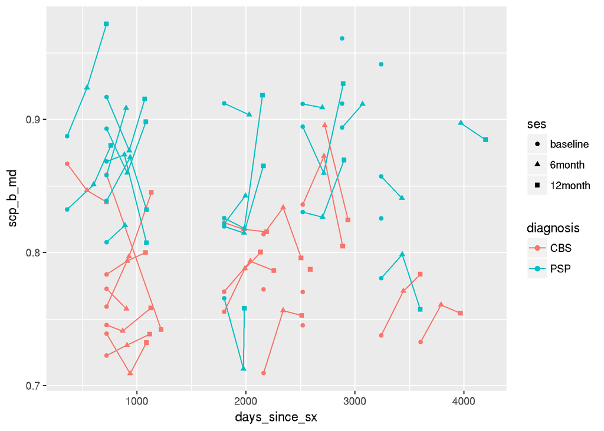

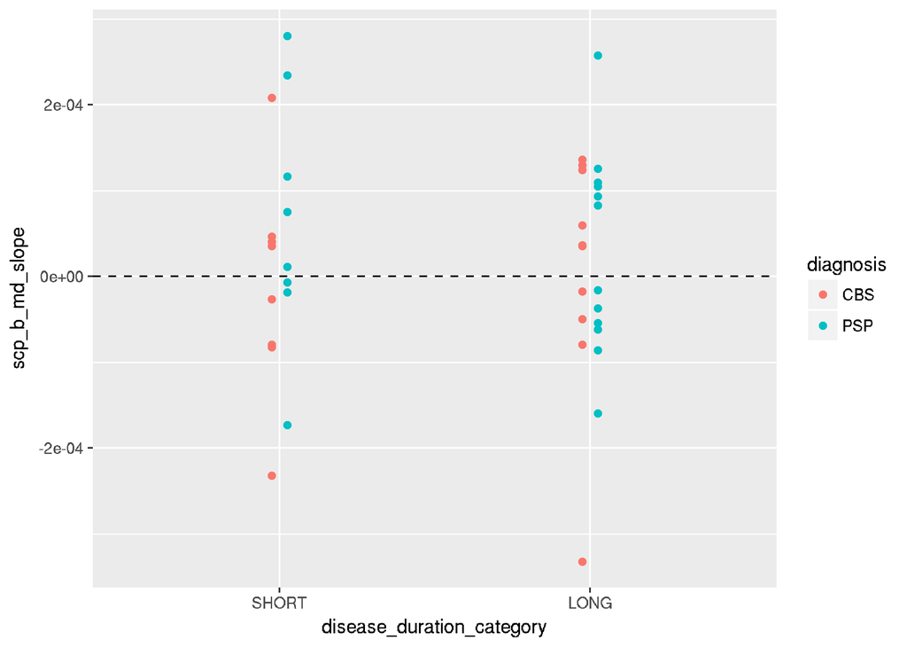

t.test for SHORT vs LONG group diff in slope among CBS:

```r
t.test(scp_b_md_slope~disease_duration_category, data=mydata_long,subset= diagnosis=="CBS")$p.value
```

```
## [1] 0.8101821
```

t.test for SHORT vs LONG group diff in slope among PSP:

```r
t.test(scp_b_md_slope~disease_duration_category, data=mydata_long,subset= diagnosis=="PSP")$p.value
```

```
## [1] 0.5798734
```

# Sup. Cerebellar Peduncle FA

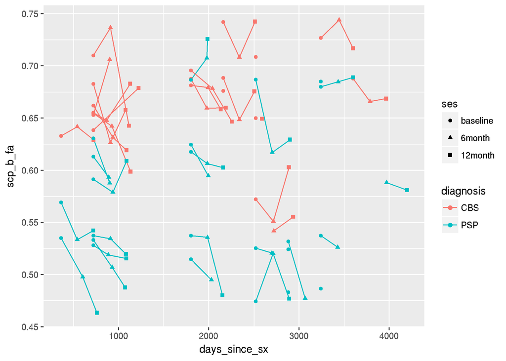

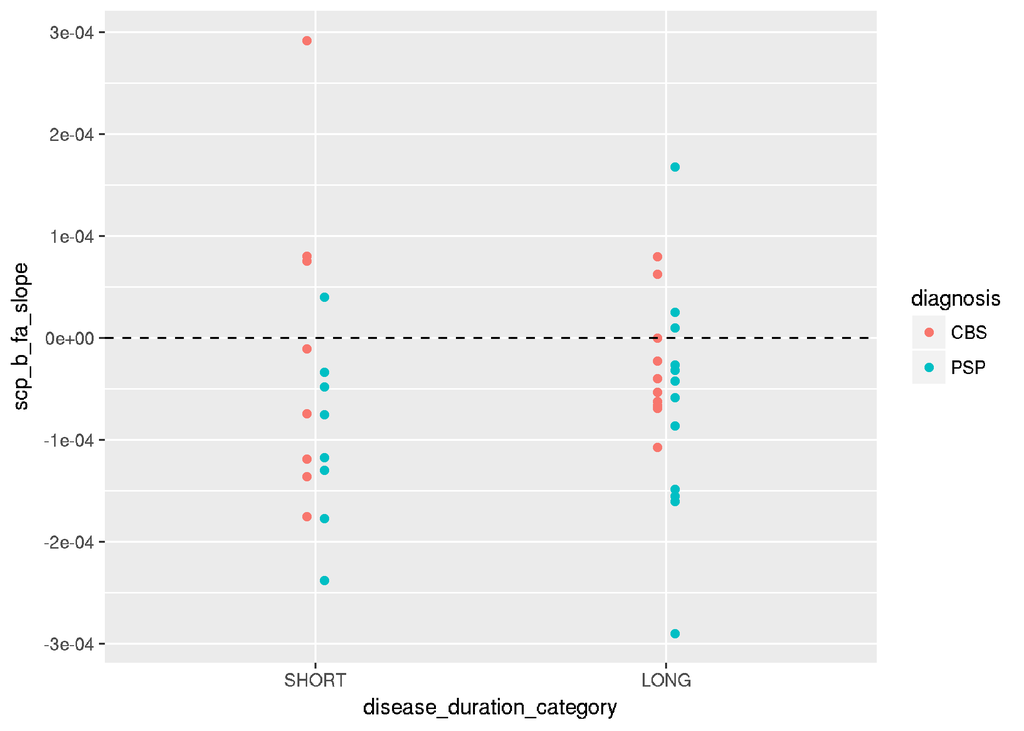

t.test for SHORT vs LONG group diff in slope among CBS:

```r
t.test(scp_b_fa_slope~disease_duration_category, data=mydata_long,subset= diagnosis=="CBS")$p.value
```

```
## [1] 0.7437332
```

t.test for SHORT vs LONG group diff in slope among PSP:

```r
t.test(scp_b_fa_slope~disease_duration_category, data=mydata_long,subset= diagnosis=="PSP")$p.value
```

```
## [1] 0.5047522
```

# Precentral+Postcentral Grey Matter Volume

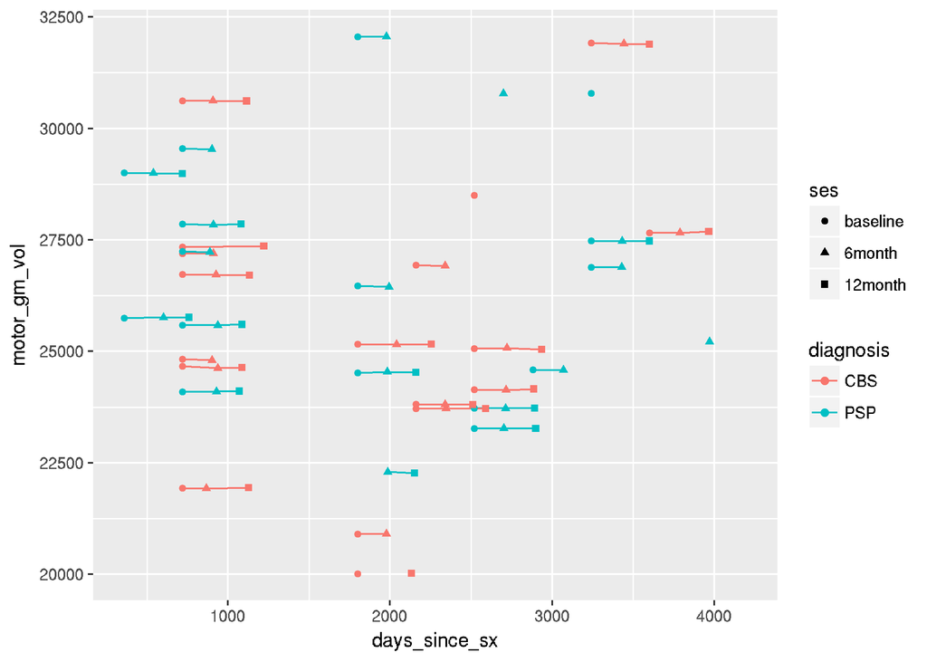

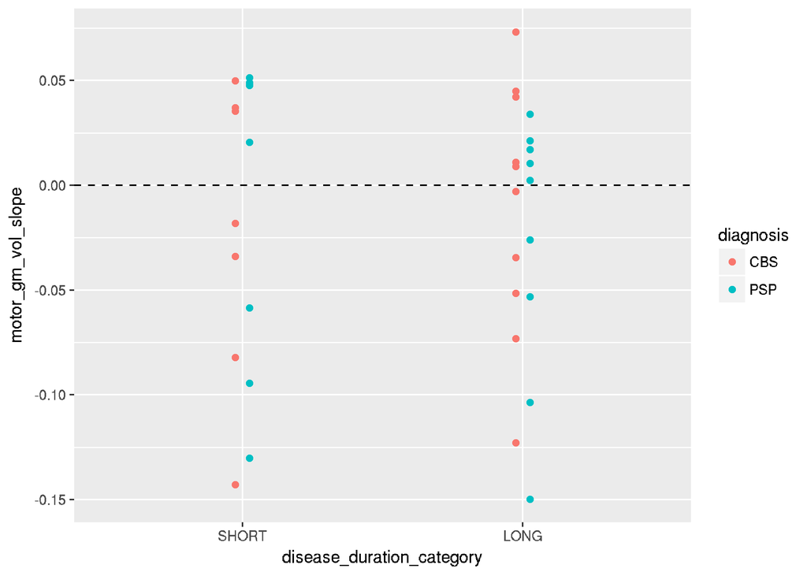

t.test for SHORT vs LONG group diff in slope among CBS:

```r
t.test(motor_gm_vol_slope~disease_duration_category, data=mydata_long,subset= diagnosis=="CBS")$p.value
```

```
## [1] 0.7296886
```

t.test for SHORT vs LONG group diff in slope among PSP:

```r
t.test(motor_gm_vol_slope~disease_duration_category, data=mydata_long,subset= diagnosis=="PSP")$p.value
```

```
## [1] 0.7598621
```

# Precentral+Postcentral White Matter Volume

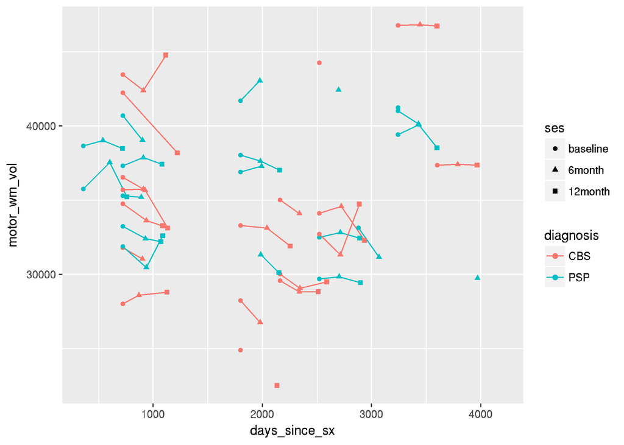

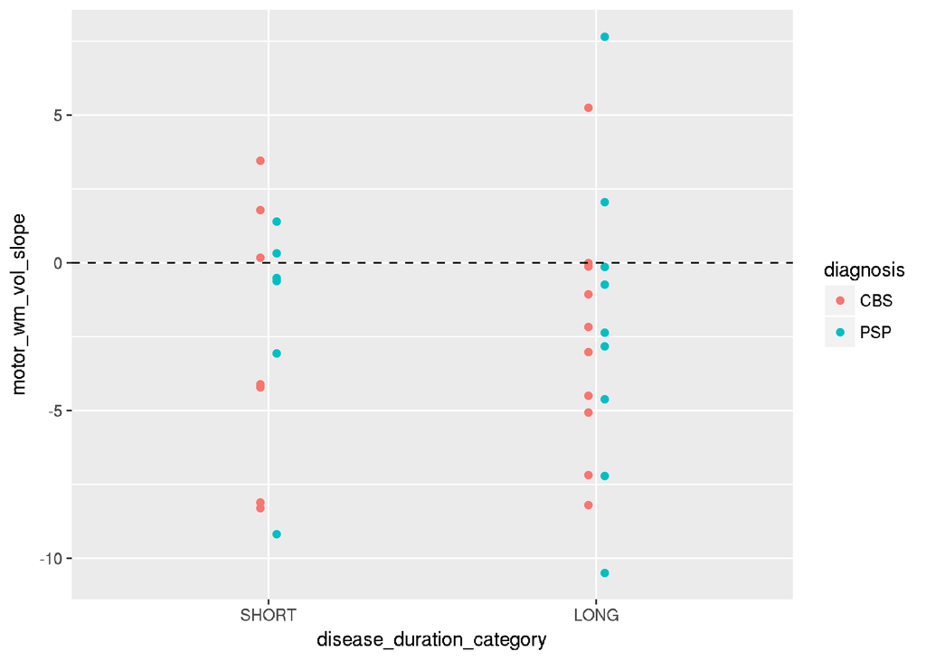

t.test for SHORT vs LONG group diff in slope among CBS:

```r
t.test(motor_wm_vol_slope~disease_duration_category, data=mydata_long,subset= diagnosis=="CBS")$p.value
```

```
## [1] 0.944938
```

t.test for SHORT vs LONG group diff in slope among PSP:

```r
t.test(motor_wm_vol_slope~disease_duration_category, data=mydata_long,subset= diagnosis=="PSP")$p.value
```

```
## [1] 0.8805148
```

# Midbrain Volume

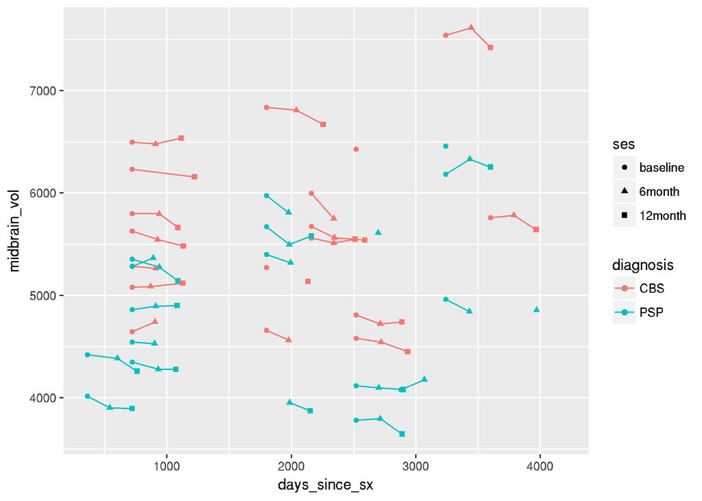

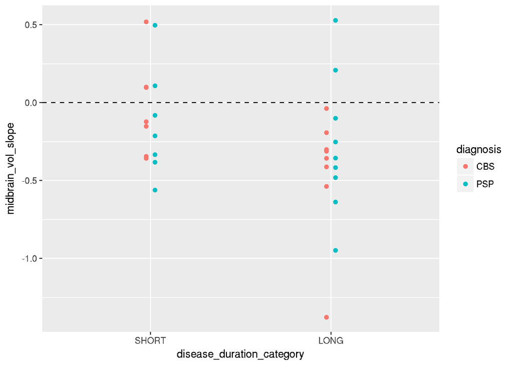

t.test for SHORT vs LONG group diff in slope among CBS:

```r
t.test(midbrain_vol_slope~disease_duration_category, data=mydata_long,subset= diagnosis=="CBS")$p.value
```

```
## [1] 0.03605806
```

t.test for SHORT vs LONG group diff in slope among PSP:

```r
t.test(midbrain_vol_slope~disease_duration_category, data=mydata_long,subset= diagnosis=="PSP")$p.value
```

```
## [1] 0.5087471
```

# Total Grey Matter Volume

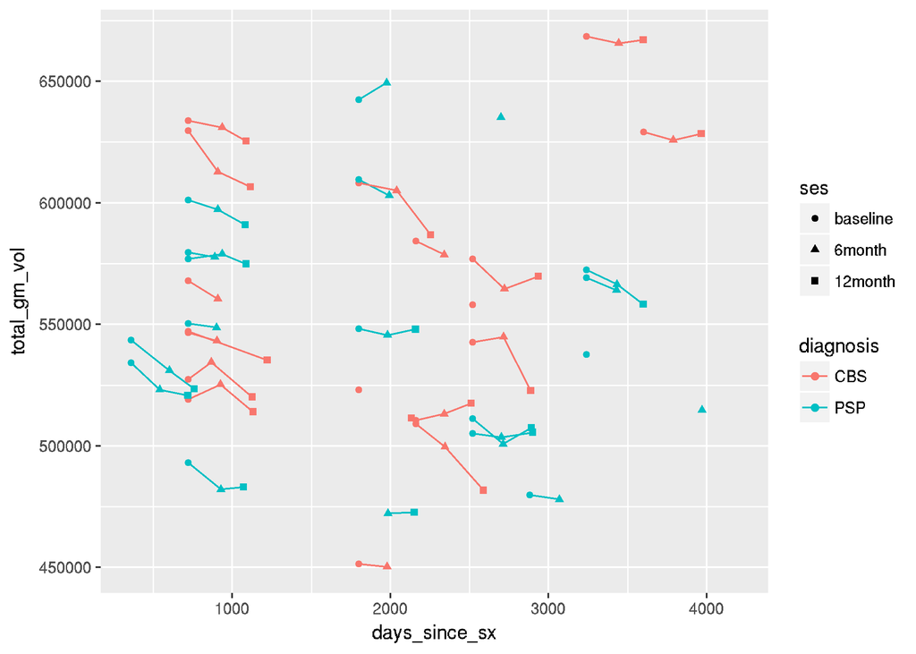

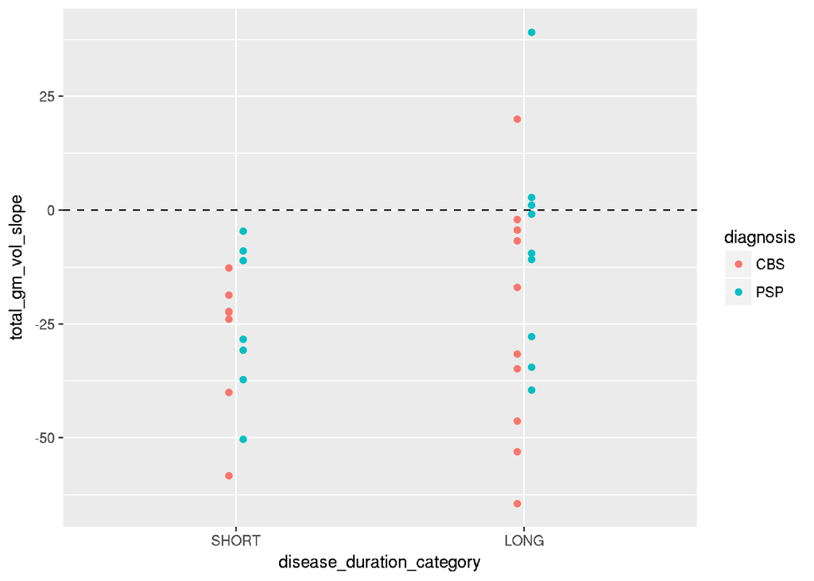

t.test for SHORT vs LONG group diff in slope among CBS:

```r
t.test(total_gm_vol_slope~disease_duration_category, data=mydata_long,subset= diagnosis=="CBS")$p.value
```

```
## [1] 0.6809166
```

t.test for SHORT vs LONG group diff in slope among PSP:

```r
t.test(total_gm_vol_slope~disease_duration_category, data=mydata_long,subset= diagnosis=="PSP")$p.value
```

```
## [1] 0.1484854
```

# Total White Matter Volume

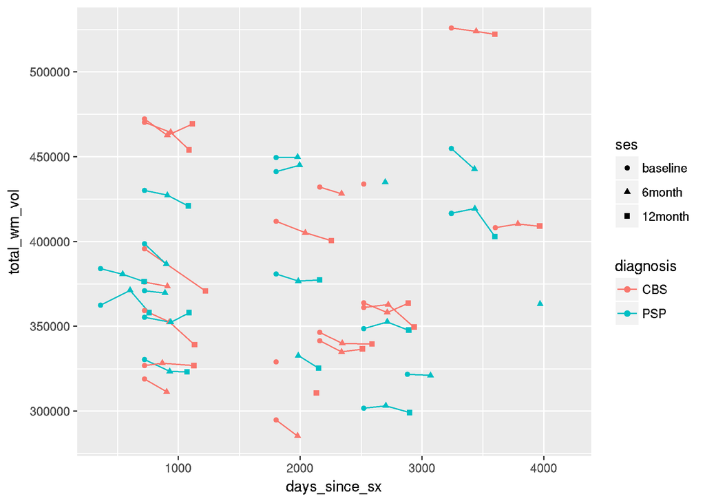

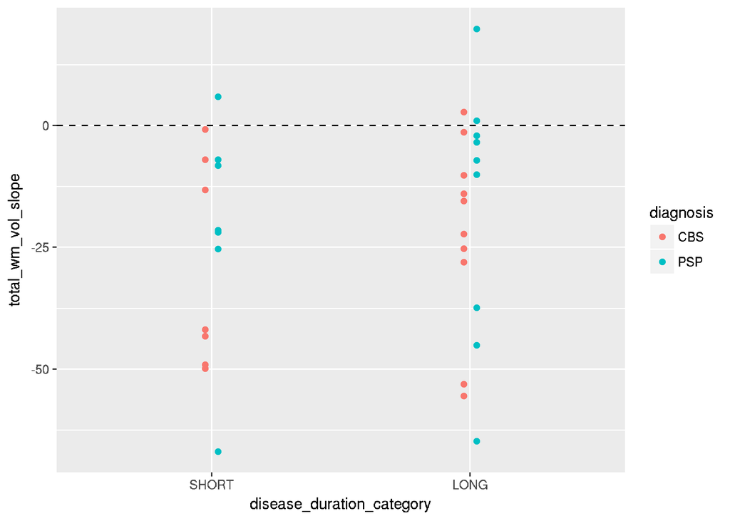

t.test for SHORT vs LONG group diff in slope among CBS:

```r
t.test(total_wm_vol_slope~disease_duration_category, data=mydata_long,subset= diagnosis=="CBS")$p.value
```

```
## [1] 0.5004565
```

t.test for SHORT vs LONG group diff in slope among PSP:

```r
t.test(total_wm_vol_slope~disease_duration_category, data=mydata_long,subset= diagnosis=="PSP")$p.value
```

```
## [1] 0.7456574
```

# Precentral FA

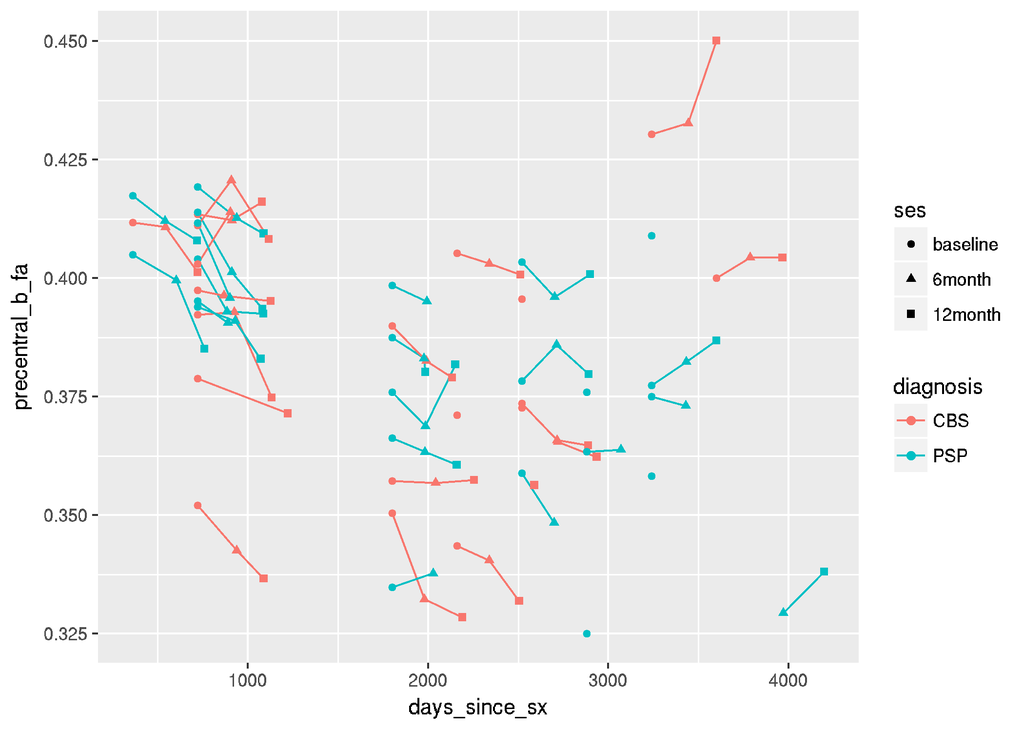

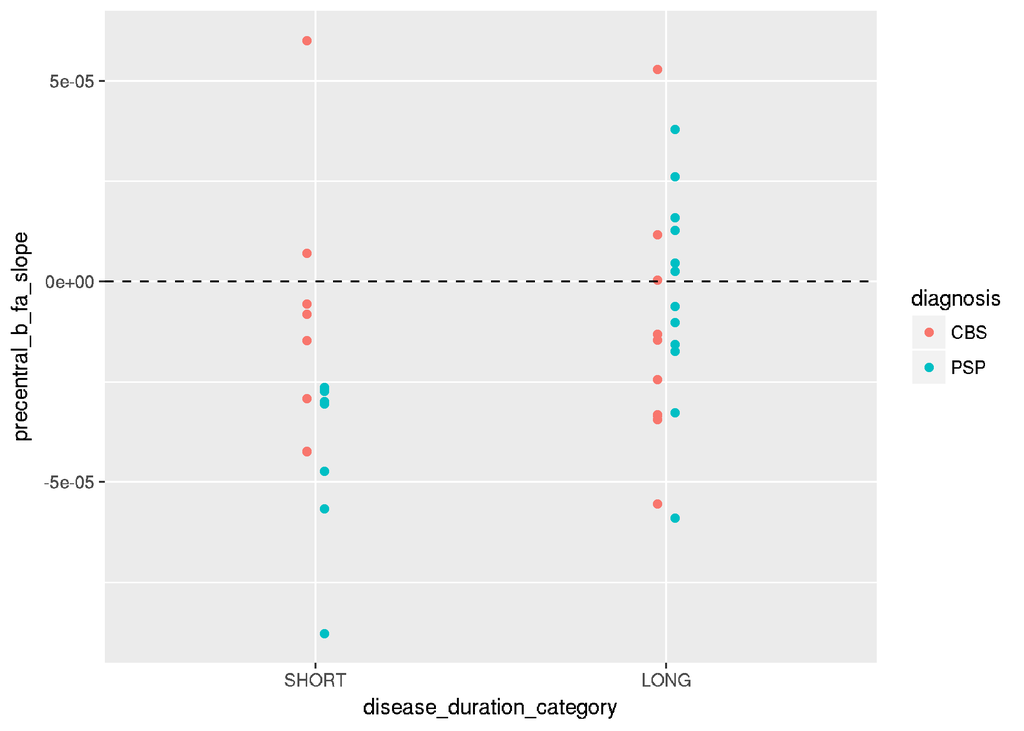

t.test for SHORT vs LONG group diff in slope among CBS:

```r
t.test(precentral_b_fa_slope~disease_duration_category, data=mydata_long,subset= diagnosis=="CBS")$p.value
```

```
## [1] 0.7493899
```

t.test for SHORT vs LONG group diff in slope among PSP:

```r
t.test(precentral_b_fa_slope~disease_duration_category, data=mydata_long,subset= diagnosis=="PSP")$p.value
```

```
## [1] 0.002524578
```

# Precentral MD

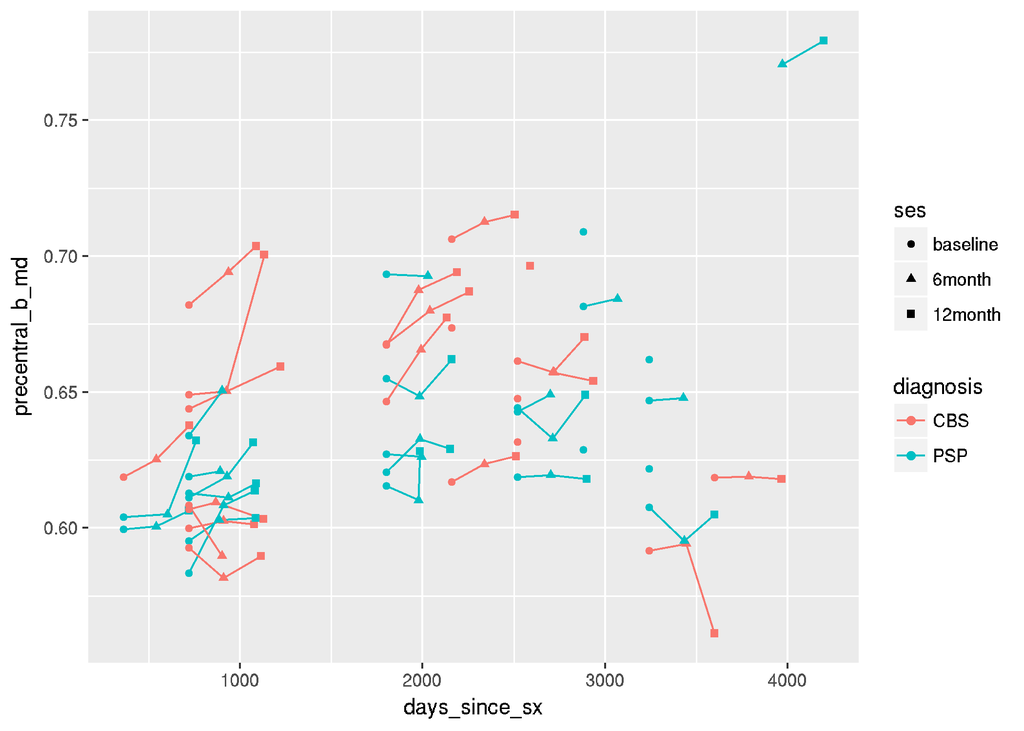

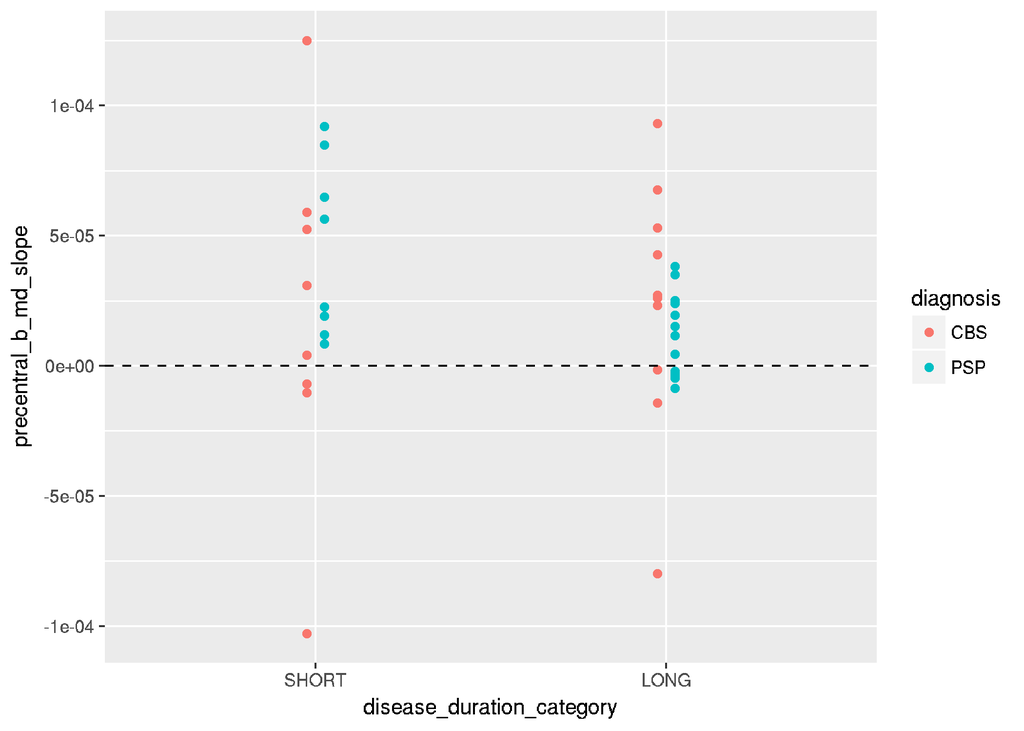

t.test for SHORT vs LONG group diff in slope among CBS:

```r
t.test(precentral_b_md_slope~disease_duration_category, data=mydata_long,subset= diagnosis=="CBS")$p.value
```

```
## [1] 0.8658294
```

t.test for SHORT vs LONG group diff in slope among PSP:

```r
t.test(precentral_b_md_slope~disease_duration_category, data=mydata_long,subset= diagnosis=="PSP")$p.value
```

```
## [1] 0.03209973
```

# Postcentral FA

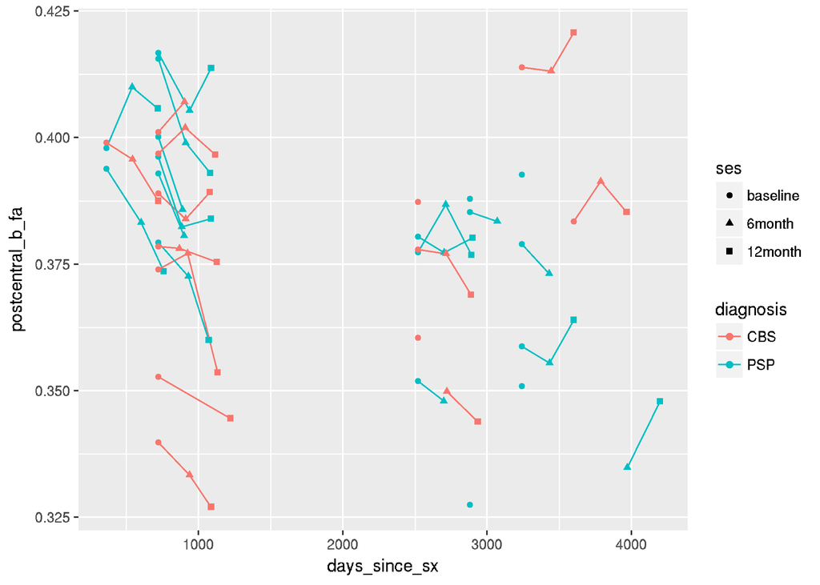

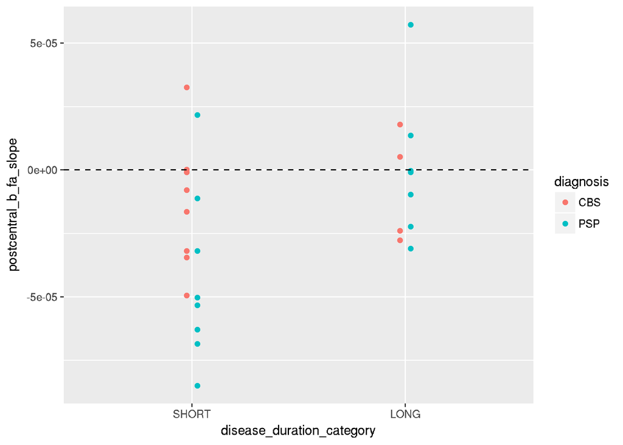

t.test for SHORT vs LONG group diff in slope among CBS:

```r
t.test(postcentral_b_fa_slope~disease_duration_category, data=mydata_long,subset= diagnosis=="CBS")$p.value
```

```
## [1] 0.6683355
```

t.test for SHORT vs LONG group diff in slope among PSP:

```r
t.test(postcentral_b_fa_slope~disease_duration_category, data=mydata_long,subset= diagnosis=="PSP")$p.value
```

```
## [1] 0.01928526
```

# Postcentral MD

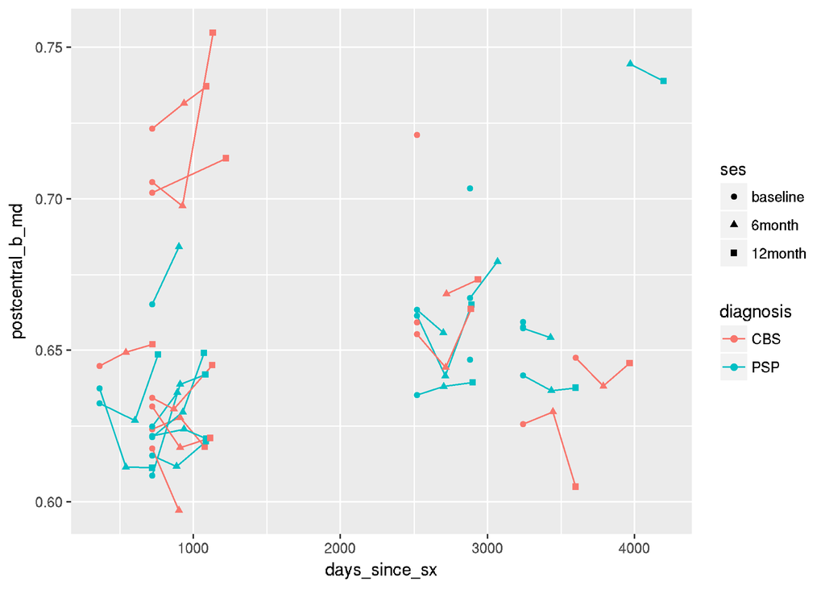

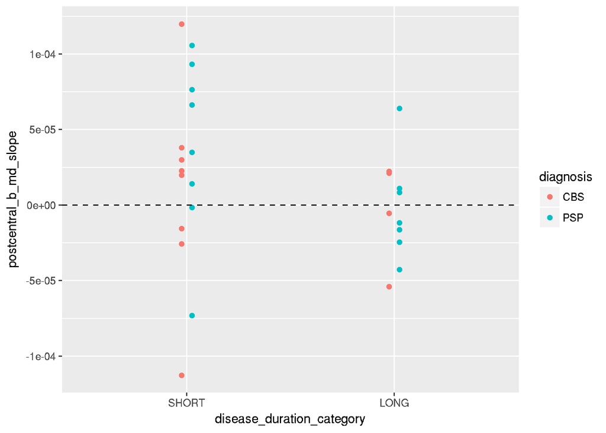

t.test for SHORT vs LONG group diff in slope among CBS:

```r
t.test(postcentral_b_md_slope~disease_duration_category, data=mydata_long,subset= diagnosis=="CBS")$p.value
```

```
## [1] 0.6550795
```

t.test for SHORT vs LONG group diff in slope among PSP:

```r
t.test(postcentral_b_md_slope~disease_duration_category, data=mydata_long,subset= diagnosis=="PSP")$p.value
```

```
## [1] 0.1205644
```

# Superior Cerebellar Peduncle AD

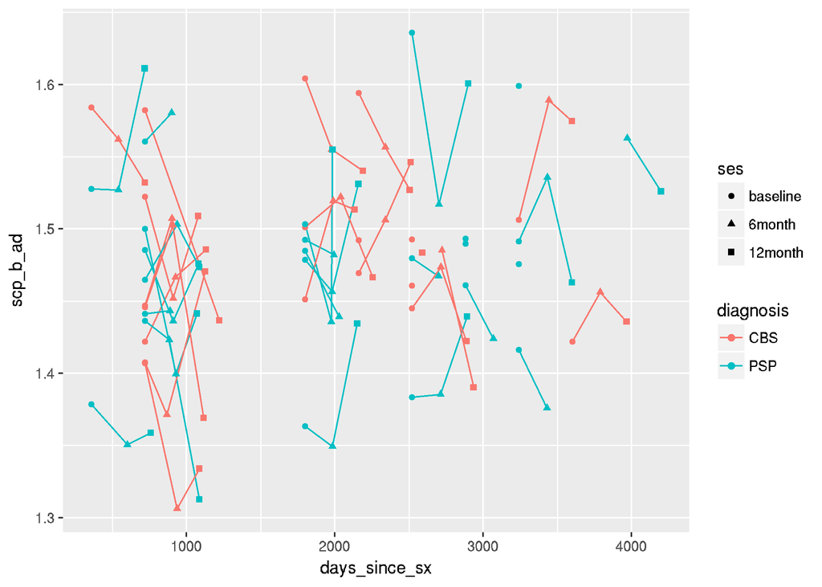

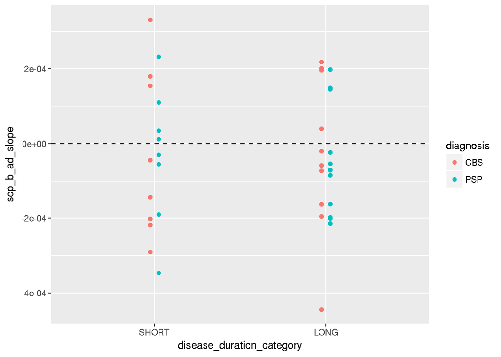

t.test for SHORT vs LONG group diff in slope among CBS:

```r
t.test(scp_b_ad_slope~disease_duration_category, data=mydata_long,subset= diagnosis=="CBS")$p.value
```

```
## [1] 0.9941252
```

t.test for SHORT vs LONG group diff in slope among PSP:

```r
t.test(scp_b_ad_slope~disease_duration_category, data=mydata_long,subset= diagnosis=="PSP")$p.value
```

```
## [1] 0.7962575
```

# Superior Cerebellar Peduncle RD

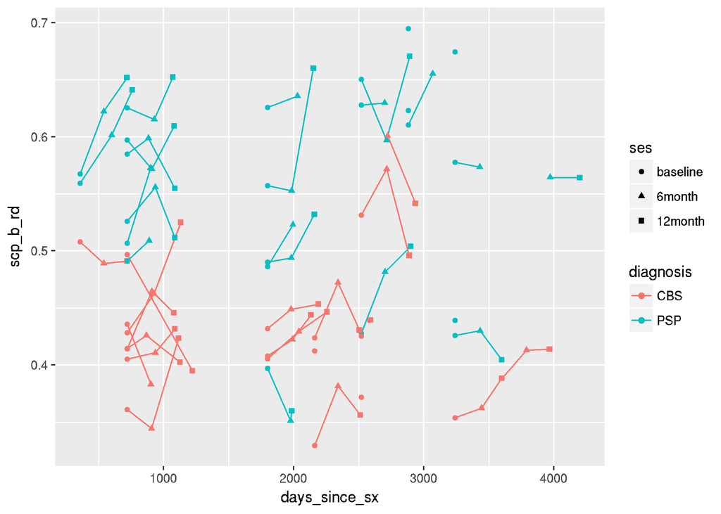

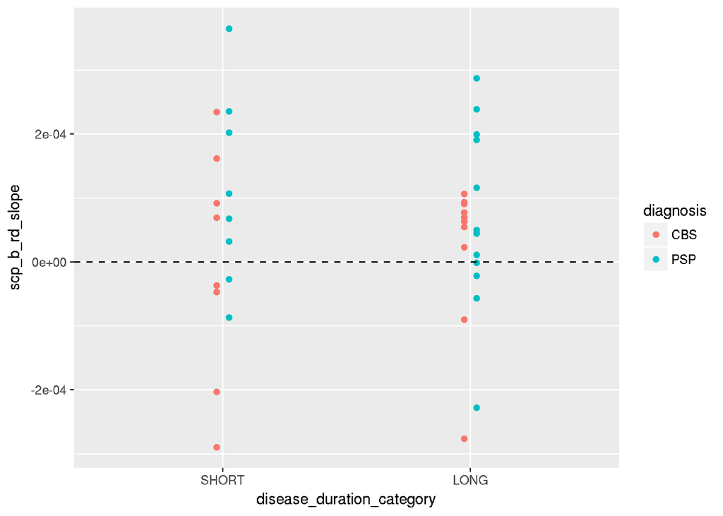

t.test for SHORT vs LONG group diff in slope among CBS:

```r
t.test(scp_b_rd_slope~disease_duration_category, data=mydata_long,subset= diagnosis=="CBS")$p.value
```

```
## [1] 0.7536128
```

t.test for SHORT vs LONG group diff in slope among PSP:

```r
t.test(scp_b_rd_slope~disease_duration_category, data=mydata_long,subset= diagnosis=="PSP")$p.value
```

```
## [1] 0.5347278
```

# Precentral Grey Matter Volume

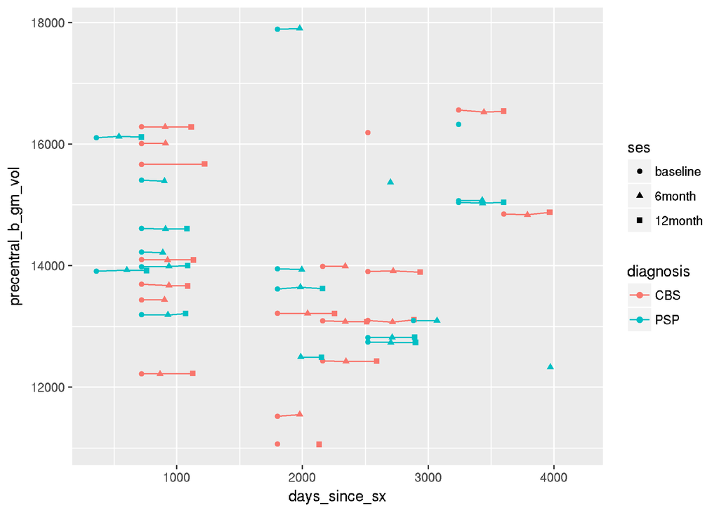

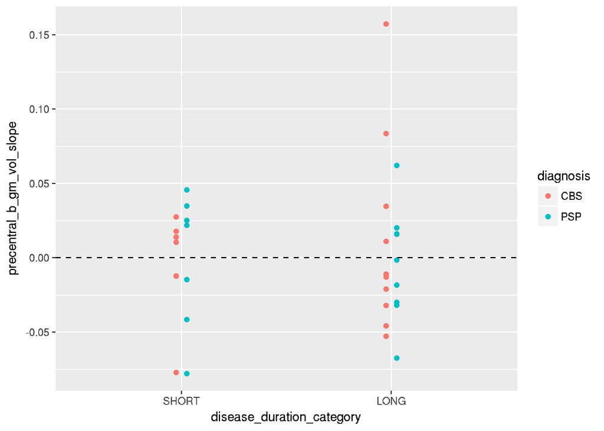

t.test for SHORT vs LONG group diff in slope among CBS:

```r
t.test(precentral_b_gm_vol_slope~disease_duration_category, data=mydata_long,subset= diagnosis=="CBS")$p.value
```

```
## [1] 0.534003
```

t.test for SHORT vs LONG group diff in slope among PSP:

```r
t.test(precentral_b_gm_vol_slope~disease_duration_category, data=mydata_long,subset= diagnosis=="PSP")$p.value
```

```
## [1] 0.8903332
```

# Precentral Grey Matter Thickness

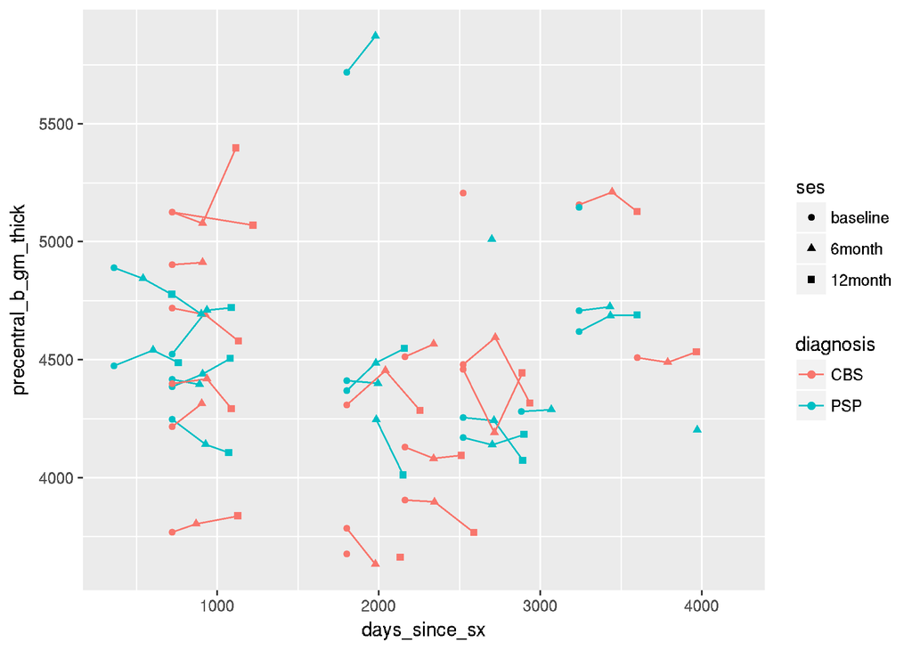

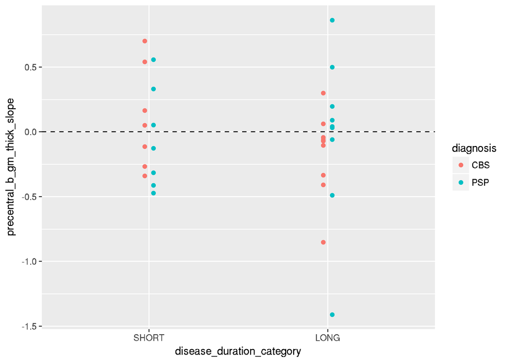

t.test for SHORT vs LONG group diff in slope among CBS:

```r
t.test(precentral_b_gm_thick_slope~disease_duration_category, data=mydata_long,subset= diagnosis=="CBS")$p.value
```

```
## [1] 0.1719783
```

t.test for SHORT vs LONG group diff in slope among PSP:

```r
t.test(precentral_b_gm_thick_slope~disease_duration_category, data=mydata_long,subset= diagnosis=="PSP")$p.value
```

```
## [1] 0.9122561
```

# Precentral White Matter Volume

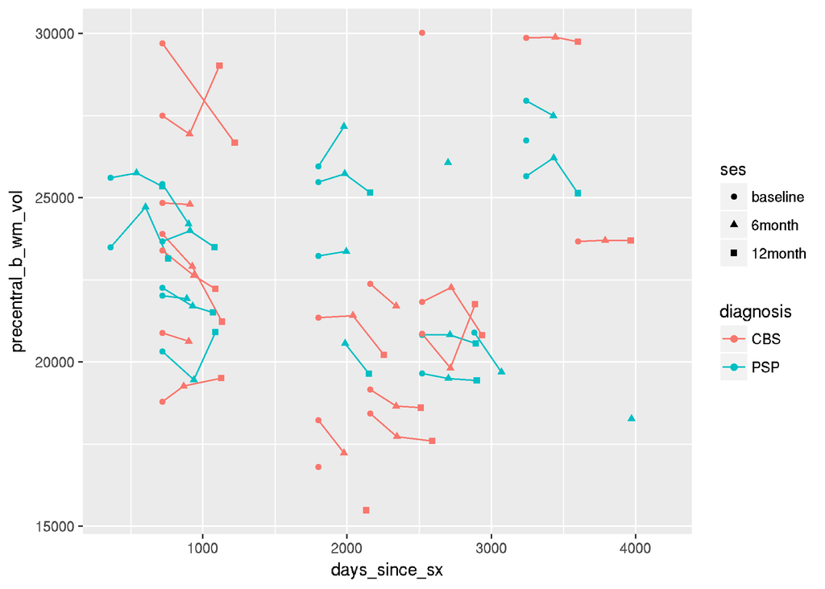

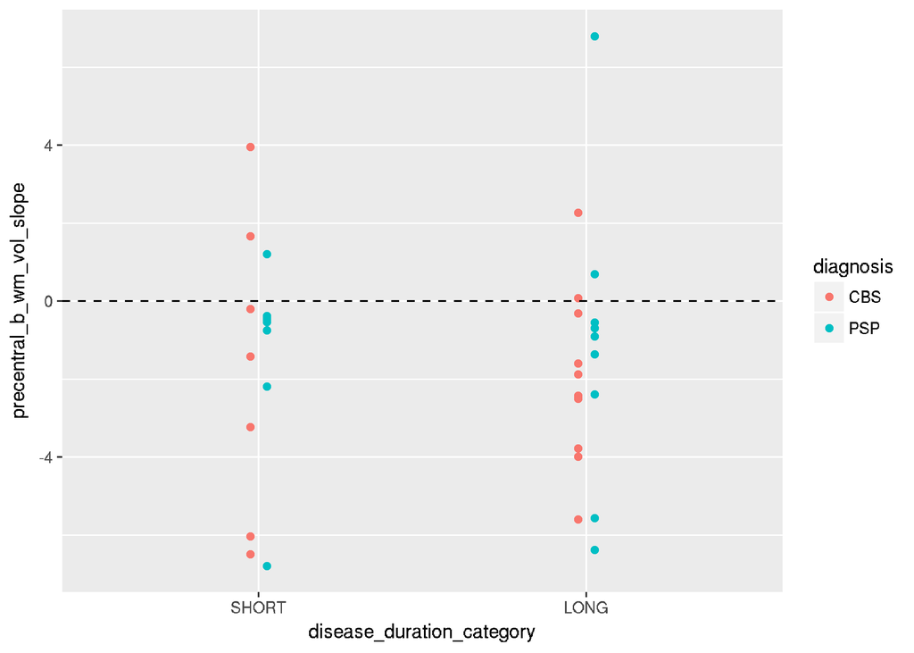

t.test for SHORT vs LONG group diff in slope among CBS:

```r
t.test(precentral_b_wm_vol_slope~disease_duration_category, data=mydata_long,subset= diagnosis=="CBS")$p.value
```

```
## [1] 0.8606234
```

t.test for SHORT vs LONG group diff in slope among PSP:

```r
t.test(precentral_b_wm_vol_slope~disease_duration_category, data=mydata_long,subset= diagnosis=="PSP")$p.value
```

```
## [1] 0.8716657
```